# Home-Credit EDA Workbook

Group 8: Jade Gosar, Karson Eilers, Paula Soutostefani

```r
#import packages here
library(tidyverse)
```

# Introduction

## Business Problem Statement

A vast amount of people have difficulty in verifying and providing proof of credit accountability when getting loans. This is a reflection of insufficient or non-existent credit histories and variance among people’s financial historical data. Without sufficient financial and credit histories, it becomes harder for lenders to identify and predict which customers are at risk of default and which are not, which can lead to mis-identifications between both groups, as well as a reduction of possible future customers that would be in fact reliable borrowers.

The purpose of the proposed project is to create a supervised analytical model to help Home Credit predict how capable each applicant is of repaying a possible loan. The analytics approach in solving this issue will be to use the different features for the current application vs. previous applications and create a supervised model based on multiple regression, and machine learning techniques like k-Fold Cross-Validation, Gaussian Mixture Model, and/or Artificial Neural Networks. Our team will also use the different transaction datasets available in order to improve the performance of the predictive model.

The main deliverable for this project will the creation of a predictive model that can be used to identify defaulters and non-defaulters and support future analysis, and a formal determination of which variables are more important when determining the prediction of the repayment ability of enterprise loans.This will benefit the lenders by providing them more reliable models and also will benefit the customers by delivering greater access to financial services that could not be available for them due to the lack of historical financial data.

Our team is composed of three students in the University of Utah MSBA program. The project will be completed by August 2, and will be separated in three main milestones: Exploratory Data Analysis, Modeling, and Final Model Presentation. The benchmark for success on this project is to be able to deliver the predictive model in a way that is reliable, effective, and cost efficient, in which we can use the current data collected without needing to expend more resources collecting future information.

## Guiding Questions & Considerations

- Should we merge the datasets and which datasets should be merged for our modeling and analysis?
- In the case of merging datasets, should we clean the data before merging or merging and then cleaning the data?
- What are the main statistical summaries of application_{train|test}.csv dataset?
- What are the datasets that we should be focusing for our Exploratory Data Analysis?
- How can you handle missing values in the datasets?
- What are the non useful datasets presented?
- Which variables in the Traning and test set will provide us a better understanding of our data and possible insights for analysis and model creation?
- Which variables within the training set will be better predictors in determining the target data.
- Impute for columns with only a handful of NA values?
- For categorical variables, what is the best way to handle NA values? The NA values get left out of the graphs that are being created for the categorical variables so would it be worth it to add them into the graphs labeled under “NA”?

# Data Structure

## Data Summary

Home credit provided analysts with 10 separate tables in the form of csv files. Those include: application_train, application_test, bureau, bureau_balance, POS_CASH_balance, credit_card_balance, installments_payments, and home_credit_columns_descriptions. Each of these files holds large amounts of data (collectively 2.68GB. There are many possible features to be explored. However, much of the data is partial and cleaning each individual feature will take significant time. For the purposes of EDA, this notebook focuses on the training_data table (which has a respectable 122 features). Other sets were included for preliminary scope-finding purposes but are not necessarily incorporated into this noteobok.

```r
#this block imports all datasets except the test set for EDA purposes.
#NOTE - you must have the csv files saved within your locla github folder. Git will not sync them.

#this is the primary dataset, it contains the target variable
training_data <- read.csv('application_train.csv')

#dataset with all clients' previous credits.
bureau <- read.csv('bureau.csv')

#dataset with monthly balances of previous credits from Credit Bureau
#NOTE - joins on credit institution
#bureau_balance <- read.csv('bureau_balance.csv')

#monthly balance of client's previous loans, behavioral data
#cash_balance <- read.csv('POS_CASH_balance.csv')

#application information from previous loans
#previous_applicants <- read.csv('previous_application.csv')

#installment payment info for previous loan holders
#installment_payments <- read.csv('installments_payments.csv')

#data set with clients' credit card balances
#credit_card_balance <- read.csv('credit_card_balance.csv')
```

## Target Variable

The target variable as identified by the data provider is called “TARGET” in the application_{train|test}.csv dataset. It’s a binary variable represented by a 1 or a 0. A 1 indicates that the borrow is experiencing is either delinquient or in default. The lateness and number installment range vary. Approximately 8.1% of all borrowers in the dataset fit the target category. This suggests a significant classification imbalance that will need to be considered in future modeling/feature selection. In the next project phase (modeling), this target variable will be predicted in the testing data set.

```r
#8.1% of popultion is identified as the target (delinquent/payment hardships)
print(mean(training_data$TARGET))
```

```
## [1] 0.08072882
```

```r
#since TARGET is a binary variable, it will be factored for further analysis
training_data$TARGET <- as.factor(training_data$TARGET)

#The majority class (non-target or TARGET = 0) has 282686 observations, while the minority class has 24,825.
#This will be a major classificaiton imbalance.
summary(training_data$TARGET)
```

```
##      0      1
## 282686  24825
```

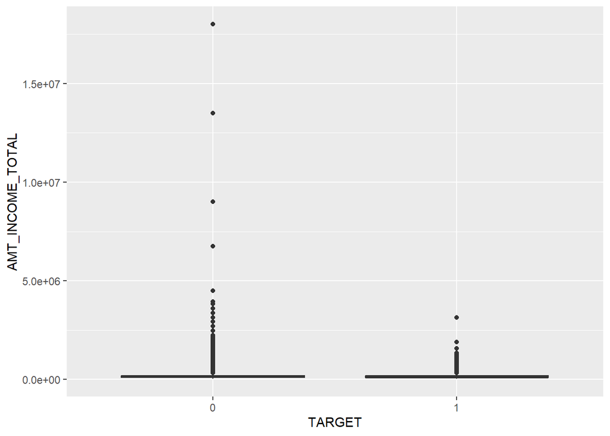

```r
#income boxplot comparing monthly income and delinquency (target)
#NOTE: there is on outlier value of $117,000,000. This is possibly a typo as it skews the rest of the set.
training_data %>%
   filter(AMT_INCOME_TOTAL < 117000000) %>%
   ggplot(aes(TARGET,AMT_INCOME_TOTAL)) + geom_boxplot()
```

```r
#generates table with delinquincy status by median income. Target borrowers appear to have lower median incomes ($135000 instead of $148,500)
training_data %>%
        select(TARGET, AMT_INCOME_TOTAL) %>%
        group_by(TARGET) %>%
        summarise(median(AMT_INCOME_TOTAL))
```

```
## # A tibble: 2 × 2
##   TARGET `median(AMT_INCOME_TOTAL)`
##   <fct>                       <dbl>
## 1 0                          148500
## 2 1                          135000
```

## Data Formatting

As we delved into the large swaths of data, we discovered a great mess. Improperly formatted data, significant numbers of missing observations for certain features, and major outliers will prove to be a challenge in the subsequent modeling phase. We address some of these issues below.

### Correcting Categorical Data Types

After looking at the summary data, we noticed that the character columns are not represented very well through the summary function. To combat this problem, we decided to factor the variables that contained categorical data in order to better understand the data structure that each column holds. This will allow for the summary function to properly handle the type of data in the columns below to show the number contained in each category.

```r
# Select character columns that contain categorical data to turn into factor variables
columns <- c("NAME_CONTRACT_TYPE", "CODE_GENDER", "FLAG_OWN_CAR", "FLAG_OWN_REALTY", "NAME_INCOME_TYPE", "NAME_EDUCATION_TYPE", "NAME_FAMILY_STATUS", "NAME_HOUSING_TYPE", "WEEKDAY_APPR_PROCESS_START", "ORGANIZATION_TYPE", "NAME_TYPE_SUITE")

# Loop over the columns selected and convert them to factors
for (column in columns) {
  training_data[[column]] <- factor(training_data[[column]])
  print(paste("Summary of", column))
  print(summary(training_data[[column]]))
}
```

```
## [1] "Summary of NAME_CONTRACT_TYPE"
##      Cash loans Revolving loans
##          278232           29279
## [1] "Summary of CODE_GENDER"
##      F      M    XNA
## 202448 105059      4
## [1] "Summary of FLAG_OWN_CAR"
##      N      Y
## 202924 104587
## [1] "Summary of FLAG_OWN_REALTY"
##      N      Y
##  94199 213312
## [1] "Summary of NAME_INCOME_TYPE"
##          Businessman Commercial associate      Maternity leave
##                   10                71617                    5
##            Pensioner        State servant              Student
##                55362                21703                   18
##           Unemployed              Working
##                   22               158774
## [1] "Summary of NAME_EDUCATION_TYPE"
##               Academic degree              Higher education
##                           164                         74863
##             Incomplete higher               Lower secondary
##                         10277                          3816
## Secondary / secondary special
##                        218391
## [1] "Summary of NAME_FAMILY_STATUS"
##       Civil marriage              Married            Separated
##                29775               196432                19770
## Single / not married              Unknown                Widow
##                45444                    2                16088
## [1] "Summary of NAME_HOUSING_TYPE"
##     Co-op apartment   House / apartment Municipal apartment    Office apartment
##                1122              272868               11183                2617
##    Rented apartment        With parents
##                4881               14840
## [1] "Summary of WEEKDAY_APPR_PROCESS_START"
##    FRIDAY    MONDAY  SATURDAY    SUNDAY  THURSDAY   TUESDAY WEDNESDAY
##     50338     50714     33852     16181     50591     53901     51934
## [1] "Summary of ORGANIZATION_TYPE"
```

[output cut: 30 more lines]

```
##          Trade: type 1          Trade: type 2          Trade: type 3
##                    348                   1900                   3492
##          Trade: type 4          Trade: type 5          Trade: type 6
##                     64                     49                    631
##          Trade: type 7      Transport: type 1      Transport: type 2
##                   7831                    201                   2204
##      Transport: type 3      Transport: type 4             University
##                   1187                   5398                   1327
##                    XNA
##                  55374
## [1] "Summary of NAME_TYPE_SUITE"
##                        Children          Family Group of people         Other_A
##            1292            3267           40149             271             866
##         Other_B Spouse, partner   Unaccompanied
##            1770           11370          248526
```

### Investigating N/A Values

The number of missing values ranges widely from feature to feature. Some are missing thousands of observations, others only a handful. Features with large percentages of missing values will be dropped during the modeling phase. We plan to impute values for features with small amounts of missing observations (e.g., AMT_ANNUITY only has 12 missing values).

```r
#There are a total of 8,388,094 missing values in the training data set. Are they evenly distributed or focused in one/more variables?
sum(is.na(training_data))
```

```
## [1] 8388094
```

```r
#summary of NAs in the training data set
table(colSums(is.na(training_data)))
```

```
##
##      0      1      2     12    278    660   1021  41519  60965 148431 150007
##     61      1      1      1      1      1      4      6      1      1      3
## 153020 154350 154828 156061 163891 169682 173378 179943 182590 202929 204488
##      3      3      3      3      3      3      1      3      3      1      3
## 208642 210199 213514 214865
##      3      3      3      3
```

```r
#For loop describes number of na values in each column for easier interpretation
column_names = list()
num_nas = list()

for (i in 1:ncol(training_data)) {
  if (sum(is.na(training_data[,i])) > 0)
    {
    print(paste("THERE ARE",sum(is.na(training_data[,i])),"NA VALUES:", colnames(training_data[i])))
  }
#surpressed for readability...
#  else {
#    print(paste("There are no NA values in", colnames(training_data[i])))
#  }
}
```

```
## [1] "THERE ARE 12 NA VALUES: AMT_ANNUITY"
## [1] "THERE ARE 278 NA VALUES: AMT_GOODS_PRICE"
## [1] "THERE ARE 202929 NA VALUES: OWN_CAR_AGE"
## [1] "THERE ARE 2 NA VALUES: CNT_FAM_MEMBERS"
## [1] "THERE ARE 173378 NA VALUES: EXT_SOURCE_1"
## [1] "THERE ARE 660 NA VALUES: EXT_SOURCE_2"
## [1] "THERE ARE 60965 NA VALUES: EXT_SOURCE_3"
## [1] "THERE ARE 156061 NA VALUES: APARTMENTS_AVG"
## [1] "THERE ARE 179943 NA VALUES: BASEMENTAREA_AVG"
## [1] "THERE ARE 150007 NA VALUES: YEARS_BEGINEXPLUATATION_AVG"
## [1] "THERE ARE 204488 NA VALUES: YEARS_BUILD_AVG"
## [1] "THERE ARE 214865 NA VALUES: COMMONAREA_AVG"
## [1] "THERE ARE 163891 NA VALUES: ELEVATORS_AVG"
## [1] "THERE ARE 154828 NA VALUES: ENTRANCES_AVG"
## [1] "THERE ARE 153020 NA VALUES: FLOORSMAX_AVG"
```

[output cut: 46 more lines]